# Onyango_HW2_9.4.21

### Exercise 8

The next histogram will show newborn birth weight split by the newborns’ sex.

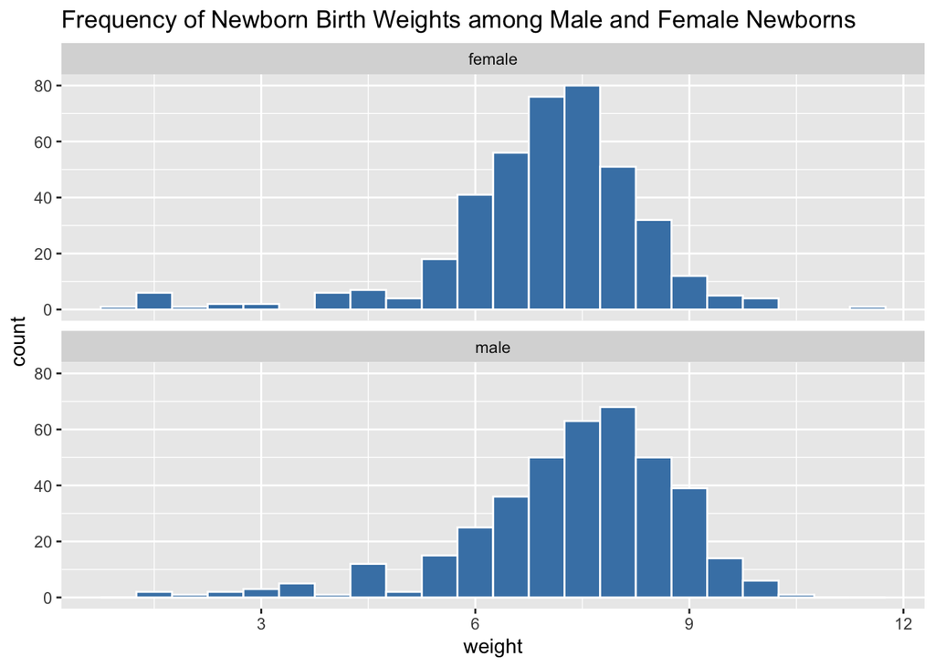

```r
ggplot (data = nc, aes(x = weight)) +
  geom_histogram(binwidth = 0.5, color = "white", fill = "steelblue") + facet_wrap(~ gender, ncol = 1) +
  labs(title = "Frequency of Newborn Birth Weights among Male and Female Newborns")
```

#### Preparing for exercise 9 and 10.

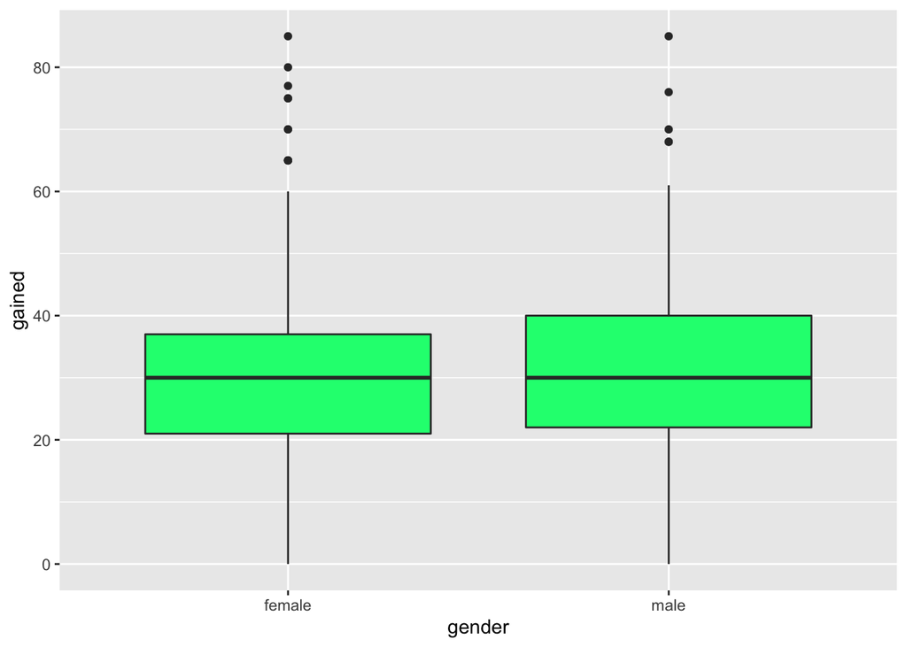

```r
ggplot(data = nc, aes(x = gender, y = gained)) +
  geom_boxplot(fill = "springgreen")
```

### Exercise 9

The following boxplot shows weight gained during pregnnacy split by the maturity status of mothers.

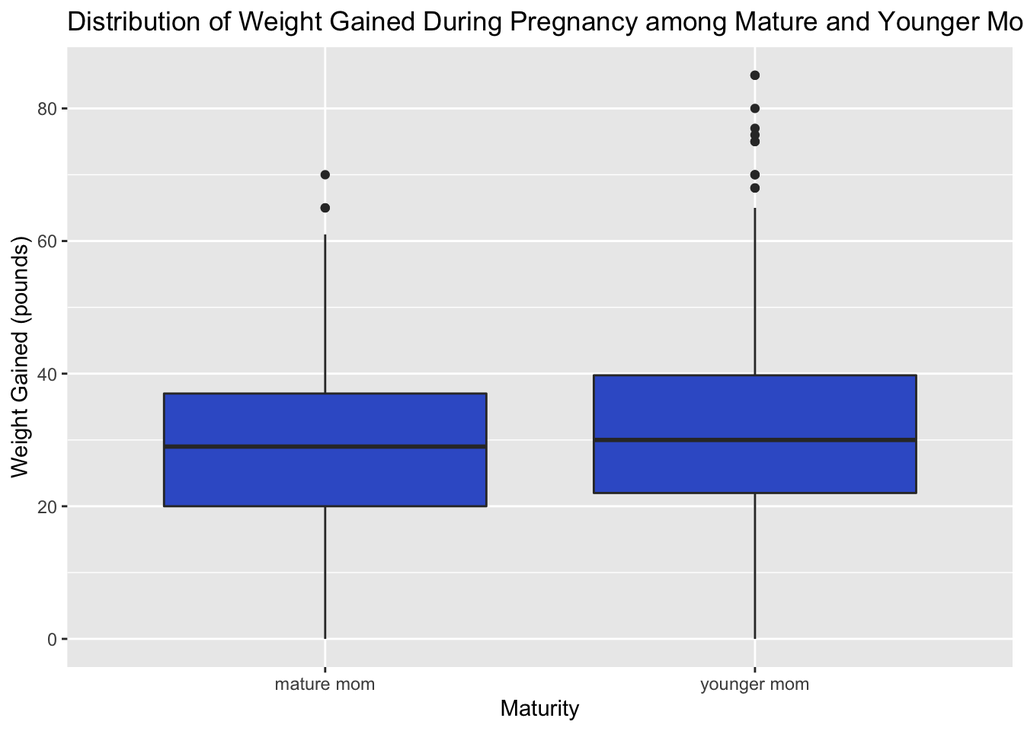

```r
ggplot(data = nc, aes(x = mature, y = gained)) +
  geom_boxplot(fill = "royalblue3") +
  labs(x = "Maturity", y = "Weight Gained (pounds)", title = "Distribution of Weight Gained During Pregnancy among Mature and Younger Moms")
```

The median of weight gain during pregnancy is higher among younger moms than mature moms.

### Exercise 10

The below boxplot shows pregnancy duration in weeks grouped by smoking habit.

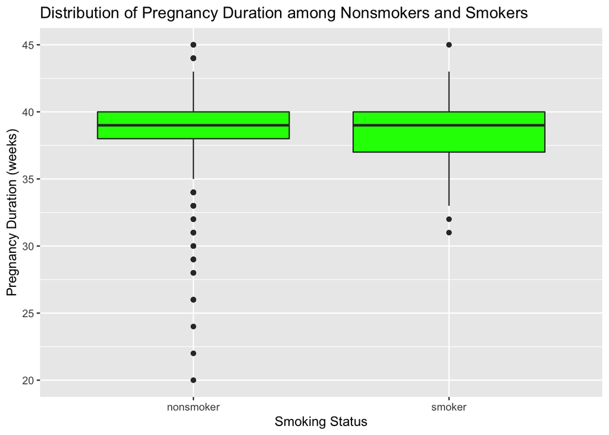

```r
ggplot(data = nc, aes(x = habit, y = weeks)) +
  geom_boxplot(fill = "green") +
  labs(x = "Smoking Status", y = "Pregnancy Duration (weeks)", title = "Distribution of Pregnancy Duration among Nonsmokers and Smokers")
```

### Exercise 11

I will use a histogram to assess if father’s age has a skew.

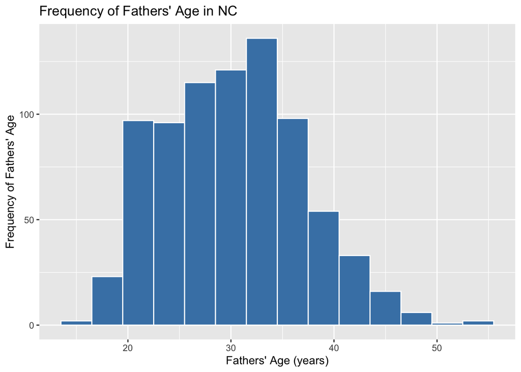

```r
ggplot(data = nc, aes(x = fage)) +
  geom_histogram(binwidth = 3, color = "white", fill = "steelblue") +
  labs( x = "Fathers' Age (years)", y = "Frequency of Fathers' Age", title = "Frequency of Fathers' Age in NC")
```

The graph is slightly skewed to the right (most data is on the left; in other words fathers tend to be ~35 and younger).

### Exercise 12

I will use a boxplot to compare median birth weights of white and non-white mothers.

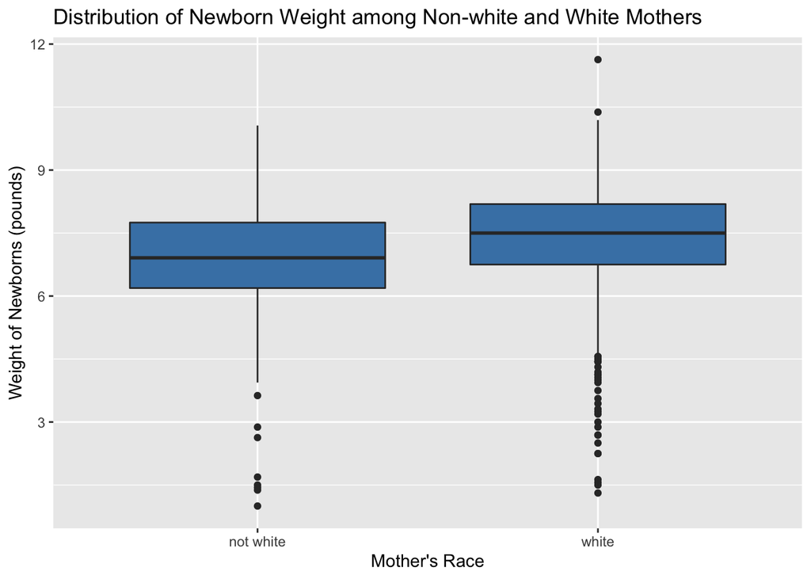

```r
ggplot(data = nc, aes(x = whitemom, y = weight)) +
  geom_boxplot(fill = "steelblue") +
  labs(x = "Mother's Race", y = "Weight of Newborns (pounds)", title = "Distribution of Newborn Weight among Non-white and White Mothers")
```

The median birth weight of newborns is greater among white mothers than non-white mothers.

### Exercise 13

I will use a scatterplot to assess if maternal age and duration of pregnancy have a relationship.

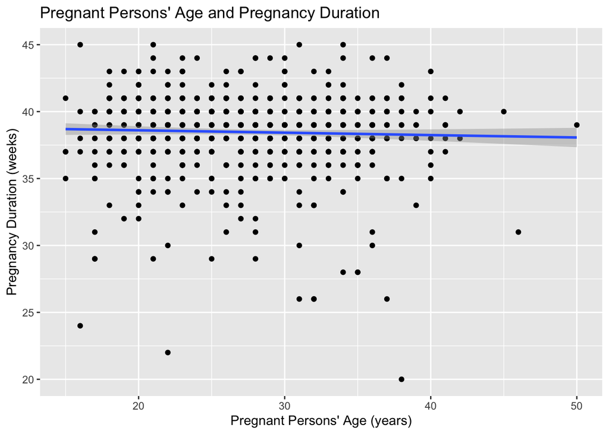

```r
ggplot(data = nc, aes(x=mage, y = weeks)) +
  geom_point() +
  geom_smooth(method = "lm") +
  labs( x = "Pregnant Persons' Age (years)", y = "Pregnancy Duration (weeks)", title = "Pregnant Persons' Age and Pregnancy Duration")
```

The scatterplot shows a slightly negative relationship between a person’s age and pregnancy duration. As age increases the duration of pregnancy decreases slightly. The slope of the line is not a large magnitude and many points fall above and below so it is a very week association based on this plot.

## PS 03: Data Wrangling

To prepare for the data wrangling exercises I loaded the Texas housing data.

```r
data(txhousing)
glimpse(txhousing)
```

```
## Rows: 8,602
## Columns: 9
## $ city      <chr> "Abilene", "Abilene", "Abilene", "Abilene", "Abilene", "Abil…
## $ year      <int> 2000, 2000, 2000, 2000, 2000, 2000, 2000, 2000, 2000, 2000, …
## $ month     <int> 1, 2, 3, 4, 5, 6, 7, 8, 9, 10, 11, 12, 1, 2, 3, 4, 5, 6, 7, …
## $ sales     <dbl> 72, 98, 130, 98, 141, 156, 152, 131, 104, 101, 100, 92, 75, …
## $ volume    <dbl> 5380000, 6505000, 9285000, 9730000, 10590000, 13910000, 1263…
## $ median    <dbl> 71400, 58700, 58100, 68600, 67300, 66900, 73500, 75000, 6450…
## $ listings  <dbl> 701, 746, 784, 785, 794, 780, 742, 765, 771, 764, 721, 658, …
## $ inventory <dbl> 6.3, 6.6, 6.8, 6.9, 6.8, 6.6, 6.2, 6.4, 6.5, 6.6, 6.2, 5.7, …
## $ date      <dbl> 2000.000, 2000.083, 2000.167, 2000.250, 2000.333, 2000.417, …
```

#### Question 1

I viewed the data using View in the console.  
The last city listed in the data set is Wichita Falls.

#### Question 2

I used the help function to view descriptions of the variables.

```r
?txhousing
```

“Listings” describes total active listings.

#### Question 3

I will write a chunk to remove the inventory variable and save the results in a dataframe called txhousing.

```r
txhousing <- txhousing |> select(-inventory)
```

There are now 8 variables instead of 9.

#### Question 4

I will now make a data set called dallas_sub with only data from 2012 and 2013.

```r
dallas_sub <- txhousing |> filter(year == 2012 | year == 2013, city == "Dallas")
```

There are 24 observations across 8 variables for Dallas in years 2012 and 2013 (remember that the inventory variable was removed in an earlier chunk).

#### Question 5

I will add a column to the dallas_sub data with a new variable for percentage of listings that were sold.

```r
dallas_sub <- dallas_sub |> mutate(prct_sold = sales/listings * 100)
```

There are now 9 variables in the Dallas data set.

#### Question 6

Now I will calculate the average percent of listings sold in Dallas grouped by month and save the results in a data frame called dallas_summary.

```r
dallas_summary <- dallas_sub |> group_by(month) |> summarize(prct_sold = mean(prct_sold))
```

#### Question 7

I will arrange the data in dallas_summary in descending order.

```r
dallas_summary |> arrange(desc(prct_sold))
```

```
## # A tibble: 12 × 2
##    month prct_sold
##    <int>     <dbl>
##  1     8      38.5
##  2     5      38.2
##  3     6      37.2
##  4     7      37.1
##  5    12      35.5
##  6     4      34.5
##  7     3      32.2
##  8    10      32.1
##  9     9      31.8
## 10    11      30.6
## 11     2      23.5
## 12     1      20.5
```

This arrangement shows that August had the greatest average of percentage of listings sold. #### Question 8 I will run and explain the following code.

```r
txhousing |>
  filter(year == 2012 | year == 2013, city == "Dallas") |>
  mutate(prct_sold = sales/listings *100) |>
  group_by(month) |>
  summarize(mean_prct_sold = mean(prct_sold)) |>
  arrange(desc(mean_prct_sold))
```

```
## # A tibble: 12 × 2
##    month mean_prct_sold
##    <int>          <dbl>
##  1     8           38.5
##  2     5           38.2
##  3     6           37.2
##  4     7           37.1
##  5    12           35.5
##  6     4           34.5
##  7     3           32.2
##  8    10           32.1
##  9     9           31.8
## 10    11           30.6
## 11     2           23.5
## 12     1           20.5
```

This code first filtered the Texas housing data by years to include only 2012 and 2013. It also filtered by city to include only data from Dallas. It created a variable called prct_sold and grouped averages of this new variable by month for 2012 and 2013. It arranged the summary data of this new variable in descending order. It is essentially one chunk that contains all the prior steps from questions 4-7.

#### Question 9

I will wrote a chunk to rank listings in ascending order by city in January 2015.

```r
txhousing |> filter(year == 2015, month == 1) |> arrange(listings)
```

```
## # A tibble: 46 × 8
##    city             year month sales   volume median listings  date
##    <chr>           <int> <int> <dbl>    <dbl>  <dbl>    <dbl> <dbl>
##  1 San Marcos       2015     1    18  3376703 150000       85  2015
##  2 Garland          2015     1   114 17591250 135800      198  2015
##  3 Irving           2015     1    82 20208733 157800      278  2015
##  4 Victoria         2015     1    54 10362907 172500      280  2015
##  5 Nacogdoches      2015     1    20  3222150 140000      284  2015
##  6 Paris            2015     1    25  3611892 123300      299  2015
##  7 Brazoria County  2015     1    69 10382931 146000      301  2015
##  8 Odessa           2015     1    63 10040640 156200      308  2015
##  9 Texarkana        2015     1    75  9330521 101400      317  2015
## 10 Lufkin           2015     1    37  6865950 134000      404  2015
## # … with 36 more rows
```

The tibble shows that San Marcos at 85 listings had the fewest in January 2015.

#### Question 10

I will now write a chunk to display houses sold in descending order in Texas in 2012.

```r
txhousing |> filter(year == 2012) |> arrange(desc(sales))
```

```
## # A tibble: 552 × 8
##    city     year month sales     volume median listings  date
##    <chr>   <int> <int> <dbl>      <dbl>  <dbl>    <dbl> <dbl>
##  1 Houston  2012     8  7112 1566297243 163900    27090 2013.
##  2 Houston  2012     6  6990 1620900791 170700    28834 2012.
##  3 Houston  2012     7  6842 1541655520 169300    28514 2012.
##  4 Houston  2012     5  6743 1565958406 168000    28819 2012.
##  5 Houston  2012    10  5866 1280422125 162100    24828 2013.
##  6 Houston  2012     4  5629 1235085496 161100    29111 2012.
##  7 Houston  2012    12  5610 1335407998 171000    21632 2013.
##  8 Houston  2012     9  5479 1186230552 163300    26019 2013.
##  9 Houston  2012    11  5449 1231393037 166700    23592 2013.
## 10 Houston  2012     3  5389 1200579097 161700    28548 2012.
## # … with 542 more rows
```

In 2012, the month with the most sales in Texas was August.

#### Question 11

I will create a table that shows total number of houses sold in Austin in 2000 and 2001, and the total number of houses sold in Dallas in 2000 and 2001.

```r
austin <- txhousing |> filter(city == "Austin") #creating austin set
austin |> filter (year == 2000 | year == 2001) #filtering austin set by relevant years
```

```
## # A tibble: 24 × 8
##    city    year month sales    volume median listings  date
##    <chr>  <int> <int> <dbl>     <dbl>  <dbl>    <dbl> <dbl>
##  1 Austin  2000     1  1025 173053635 133700     3084 2000
##  2 Austin  2000     2  1277 226038438 134000     2989 2000.
##  3 Austin  2000     3  1603 298557656 136700     3042 2000.
##  4 Austin  2000     4  1556 289197960 136900     3192 2000.
##  5 Austin  2000     5  1980 393073774 144700     3617 2000.
##  6 Austin  2000     6  1885 368290072 148800     3799 2000.
##  7 Austin  2000     7  1818 351539312 149300     3944 2000.
##  8 Austin  2000     8  1880 360255090 146300     3948 2001.
##  9 Austin  2000     9  1498 292799874 148700     4058 2001.
## 10 Austin  2000    10  1524 300952544 150100     4100 2001.
## # … with 14 more rows
```

```r
 austin |> mutate(austin_sum = sum(austin$sales))
```

```
## # A tibble: 187 × 9
##    city    year month sales    volume median listings  date austin_sum
##    <chr>  <int> <int> <dbl>     <dbl>  <dbl>    <dbl> <dbl>      <dbl>
##  1 Austin  2000     1  1025 173053635 133700     3084 2000      373381
##  2 Austin  2000     2  1277 226038438 134000     2989 2000.     373381
##  3 Austin  2000     3  1603 298557656 136700     3042 2000.     373381
##  4 Austin  2000     4  1556 289197960 136900     3192 2000.     373381
##  5 Austin  2000     5  1980 393073774 144700     3617 2000.     373381
##  6 Austin  2000     6  1885 368290072 148800     3799 2000.     373381
##  7 Austin  2000     7  1818 351539312 149300     3944 2000.     373381
##  8 Austin  2000     8  1880 360255090 146300     3948 2001.     373381
##  9 Austin  2000     9  1498 292799874 148700     4058 2001.     373381
## 10 Austin  2000    10  1524 300952544 150100     4100 2001.     373381
## # … with 177 more rows
```

```r
austin_sum <- sum(austin$sales) #Making sure austin_sum is added as a column.
```

Next I will repeat the steps above for Dallas.

```r
dallas <- txhousing |> filter(city == "Dallas") #creating Dallas set
dallas |> filter (year == 2000 | year == 2001)
```

```
## # A tibble: 24 × 8
##    city    year month sales    volume median listings  date
##    <chr>  <int> <int> <dbl>     <dbl>  <dbl>    <dbl> <dbl>
##  1 Dallas  2000     1  2286 375389865 124400    13316 2000
##  2 Dallas  2000     2  3247 555124812 127700    13495 2000.
##  3 Dallas  2000     3  4244 702148377 128500    13752 2000.
##  4 Dallas  2000     4  3977 667331427 132000    13752 2000.
##  5 Dallas  2000     5  4545 783197806 137100    14018 2000.
##  6 Dallas  2000     6  4738 846254912 138800    14392 2000.
##  7 Dallas  2000     7  4276 763793916 139600    14705 2000.
##  8 Dallas  2000     8  4373 770735708 134500    14607 2001.
##  9 Dallas  2000     9  3654 643046932 136000    15109 2001.
## 10 Dallas  2000    10  3601 626302634 134600    15212 2001.
## # … with 14 more rows
```

Generating dallas_sum

```r
dallas |> mutate(dallas_sum = sum(dallas$sales))
```

```
## # A tibble: 187 × 9
##    city    year month sales    volume median listings  date dallas_sum
##    <chr>  <int> <int> <dbl>     <dbl>  <dbl>    <dbl> <dbl>      <dbl>
##  1 Dallas  2000     1  2286 375389865 124400    13316 2000      816122
##  2 Dallas  2000     2  3247 555124812 127700    13495 2000.     816122
##  3 Dallas  2000     3  4244 702148377 128500    13752 2000.     816122
##  4 Dallas  2000     4  3977 667331427 132000    13752 2000.     816122
##  5 Dallas  2000     5  4545 783197806 137100    14018 2000.     816122
##  6 Dallas  2000     6  4738 846254912 138800    14392 2000.     816122
##  7 Dallas  2000     7  4276 763793916 139600    14705 2000.     816122
##  8 Dallas  2000     8  4373 770735708 134500    14607 2001.     816122
##  9 Dallas  2000     9  3654 643046932 136000    15109 2001.     816122
## 10 Dallas  2000    10  3601 626302634 134600    15212 2001.     816122
## # … with 177 more rows
```

```r
dallas_sum <- sum(dallas$sales)
```

Next I will create a dataset and table with the relevant information from both Austin and Dallas.

```r
rbind(austin, dallas)
```

```
## # A tibble: 374 × 8
##    city    year month sales    volume median listings  date
##    <chr>  <int> <int> <dbl>     <dbl>  <dbl>    <dbl> <dbl>
##  1 Austin  2000     1  1025 173053635 133700     3084 2000
##  2 Austin  2000     2  1277 226038438 134000     2989 2000.
##  3 Austin  2000     3  1603 298557656 136700     3042 2000.
##  4 Austin  2000     4  1556 289197960 136900     3192 2000.
##  5 Austin  2000     5  1980 393073774 144700     3617 2000.
##  6 Austin  2000     6  1885 368290072 148800     3799 2000.
##  7 Austin  2000     7  1818 351539312 149300     3944 2000.
##  8 Austin  2000     8  1880 360255090 146300     3948 2001.
##  9 Austin  2000     9  1498 292799874 148700     4058 2001.
## 10 Austin  2000    10  1524 300952544 150100     4100 2001.
## # … with 364 more rows
```

Will name this set austin_dallas

```r
austin_dallas <- rbind(austin, dallas)
```

Will remove all data but for sales and year.

```r
austin_dallas <- austin_dallas |> filter(year == 2000 | year == 2001) |> select(city, year, sales)
```

I will group by city and sum by group.

```r
austin_dallas |> group_by(city) |> summarize(salesum = sum(sales))
```

```
## # A tibble: 2 × 2
##   city   salesum
##   <chr>    <dbl>
## 1 Austin   37013
## 2 Dallas   92438
```

The tibble above shows correct sums for house sales in 2000 and 2001 for Austin and Dallas. Earlier tables showed values that weren’t filtered by year.